# assignment1

Marco Martinez Corral marcom@pdx.edu EE513 Assignment 1, Setup and First Captures.

**Assignment Tasks**

*1: Build the course environment from the two files on the setup page and run the smoke test notebook.* *Deliverable: the version block, the smoke test prints, showing Python, NumPy, and OpenCV versions.* **Deliverables:**

```
Python   3.12.14
Platform macOS-27.0.1-arm64-arm-64bit
Executable /Users/marco/Documents/PSU/EE513/.venv/bin/python
Python version: 3.12.14 (main, Aug 12 2026, 13:57:54) [Clang 21.0.0 (clang-2100.1.1.101)]
Python executable: /Users/marco/Documents/PSU/EE513/.venv/bin/python
[PASS] all required packages import  numpy 2.5.3, scipy 1.18.1, matplotlib 3.11.2, cv2 5.0.0, rawpy 0.27.1, imageio 2.38.0, skimage 0.26.0
[PASS] OpenCV major version is 5  found 5.0.0
[PASS] functions this course uses are present  7 of 7
```

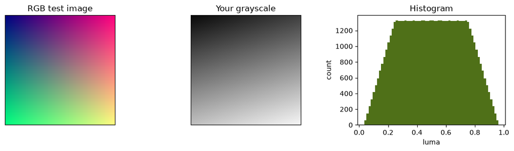

2: GitHub Repository URL: https://github.com/MarcoMartinezC/EE513Assignment1

*3: Capture one raw photograph of anything, load it with rawpy, and print raw_type, the shape and dtype of* *raw_image_visible, raw_pattern, color_desc, black_level_per_channel, and white_level.* *Deliverable: the printed output.*

**Deliverables**

```python
import sys, platform, textwrap

import rawpy
import numpy as np

# RAW image loading using rawpy.imread
# I'm using a NEF file from a Nikon Z50 Camera. Picture is from the Big Ben clock tower in London
raw =  rawpy.imread('DSC_6997.NEF')

# Print "raw" variable parameters
print("Raw Type:", raw.raw_type)
print("Shape of raw_image_visible:", raw.raw_image_visible.shape)
print("Dtype of raw_image_visible:", raw.raw_image_visible.dtype)
print("Raw Pattern:\n", raw.raw_pattern)
print("Color Desc:", raw.color_desc)
print("Black Level per Channel:", raw.black_level_per_channel)
print("White Level:", raw.white_level)
```

```
Raw Type: RawType.Flat
Shape of raw_image_visible: (3728, 5600)
Dtype of raw_image_visible: uint16
Raw Pattern:
 [[0 1]
 [3 2]]
Color Desc: b'RGBG'
Black Level per Channel: [1008, 1008, 1008, 1008]
White Level: 16383
```

4. Given that RawType.Flat, a dimension of (3728, 5600) (which matches the DX resolution of my Nikon Z50 camera), and a 2x2 matrix for the Raw pattern, this image has a Bayer mosaic. CFA Layout: b'RGBG'
5. Not applicable

*6. Capture the same scene twice without moving the camer , once as raw and once as an ordinary JPEG or HEIC. Report the file size, bit depth, and number of channels of each.*

When I took the Big Ben picture, my camera was set to save both NEF and JPG file versions of the pictures. Using exiftool on macOS, the NEF image has 14 bit sampling:

```
exiftool -BitsPerSample -NEFCompression DSC_6997.NEF
Bits Per Sample                 : 14
NEF Compression                 : Lossless
```

| Format | File Size | Bit Depth | Channels |
| --- | --- | --- | --- |
| **.NEF** | 27.1 MB | 14 bit | 1 |
| **.JPG** | 5.4 MB | 8 bit | 3 |

*7. Display a region of about 30 by 30 pixels of the raw data, zoomed so that individual pixels are visible as blocks. Deliverable: the figure, and a sentence identifying what the checkerboard texture is. It is not noise.*

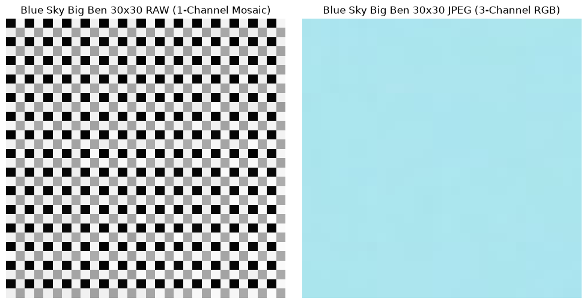

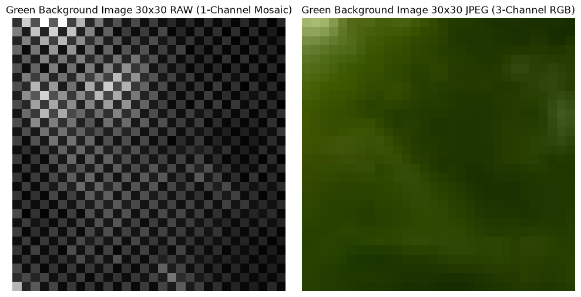

```python
import matplotlib.pyplot as plt
import matplotlib.image as mpimg

# Load NEF image and extract 30x30 region
with rawpy.imread('DSC_6997.NEF') as raw:
    raw_crop = raw.raw_image_visible[1000:1030, 1000:1030]

# JPEG loading
jpg_img = mpimg.imread('DSC_6997.JPG')
jpg_crop = jpg_img[1000:1030, 1000:1030]

# Plots
fig, axes = plt.subplots(1, 2, figsize=(10, 5))

# Plot RAW
axes[0].imshow(raw_crop, cmap='gray', interpolation='nearest')
axes[0].set_title("Blue Sky Big Ben 30x30 RAW (1-Channel Mosaic)")
axes[0].axis('off')

# JPG plot for difference checking, I wanted to see the demosaicing results
# Plot JPG and displays the demosaiced, color-interpolated result
axes[1].imshow(jpg_crop, interpolation='nearest')
axes[1].set_title("Blue Sky Big Ben 30x30 JPEG (3-Channel RGB)")
axes[1].axis('off')

plt.tight_layout()
plt.show()


# Testing with additional "green" image since checkerboard for Big Ben image does not have too many differing values
with rawpy.imread('DSC_7143.NEF') as raw:
    raw_crop = raw.raw_image_visible[1000:1030, 1000:1030]

# JPEG loading
jpg_img = mpimg.imread('DSC_7143.JPG')
jpg_crop = jpg_img[1000:1030, 1000:1030]
fig, axes = plt.subplots(1, 2, figsize=(10, 5))

# Plot RAW
axes[0].imshow(raw_crop, cmap='gray', interpolation='nearest')
axes[0].set_title("Green Background Image 30x30 RAW (1-Channel Mosaic)")
axes[0].axis('off')

# Plot JPEG
axes[1].imshow(jpg_crop, interpolation='nearest')
axes[1].set_title("Green Background Image 30x30 JPEG (3-Channel RGB)")
axes[1].axis('off')

plt.tight_layout()
plt.show()
```

The 1 channel mosaic of the green background does vary in intensity ranges as the green values are brighter, as can be seen near the top left region.

The RBG profile shows the demosaicing applied to the image; this interpolates all 3 colors in the RGB color space, producing light blue and green images for the light blue sky background and green foliage backgrounds, respectively.

JPG preview of the blue sky Big Ben image:

[figure not shown]

JPG preview of the Green Background Flag image:

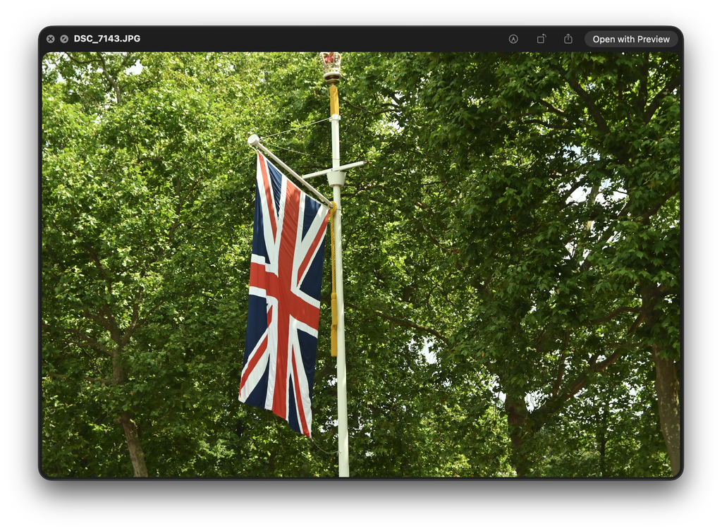

*9. Print the calibration target at 100% scale and tape it flat to card or board. Measure one square with a ruler and report the measured size in millimetres*

*Deliverable: the measured square size, and one sentence on why you will use your measured value rather than the nominal 20.0 mm.*

Measured square size: 19.9mm. This measured value will be used, as it is the real world/actual value printed out, as opposed to the pixel value fed into the printer. Since the picture will be of the paper, the actual dimensions will need to be accounted for.

*10. Capture at least 15 photographs of the target at a variety of angles, distances, and positions in the frame, including several where the board is tilted well away from parallel and several where it sits near a corner of the frame*

*11. Run cv2.findChessboardCorners with the pattern size (9, 6) on every capture and report how many succeeded.* *Deliverable: the count, and one image with the detected corners drawn on it.*

*12. Pass the successful detections to cv2.calibrateCamera and report the RMS reprojection error it returns. A rough number is fine here; Project 1 is where you will interpret it.* *Deliverable: the RMS reprojection error, and one sentence on what it means and what units it is in.*

**(See code snippet below for deliverables 10, 11, and 12)**

```
24 image files found
```

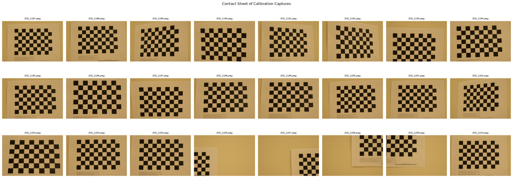

```
  no corners: DSC_1206.jpeg
  no corners: DSC_1207.jpeg
  no corners: DSC_1208.jpeg
  no corners: DSC_1209.jpeg
Corners found: 20 out of 24 images succeeded in finding corners.
```

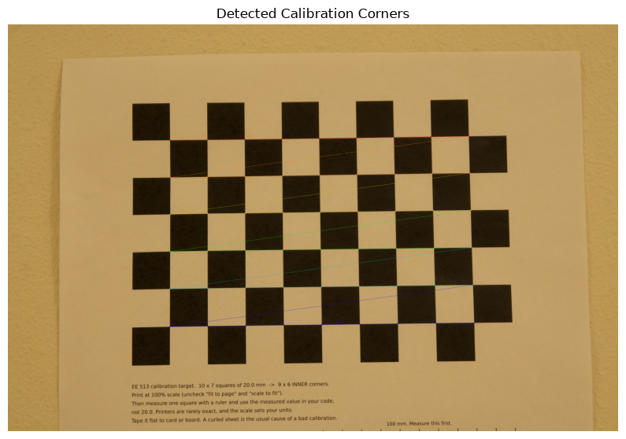

```
RMS Reprojection Error = 2.4053 px
K =
 [[1.22607047e+04 0.00000000e+00 2.76074281e+03]
 [0.00000000e+00 1.22652017e+04 1.97112373e+03]
 [0.00000000e+00 0.00000000e+00 1.00000000e+00]]
dist = [ 1.47073390e-01 -4.24906676e+00 -6.96814677e-05  3.31306898e-03
  6.79953116e+01]
```

```python
import sys
from pathlib import Path

import cv2
import matplotlib.pyplot as plt
import numpy as np

# As I am not as familiar with Python as I am with SystemVerilog/C (due to the embedded systems track classes I've taken),
# I used Gemini AI to walk me through the methods and functions present in the "02_projection_and_intrinsics" and
# "02_calibrate_your_camera" notebooks. From there, I tried to use "blocks" and snippets from those notebooks to:

# 1 set the parameters for the board
# 2 import files
# 3 set the contact sheet
# 4 find corners via a "small image" and applies this to the larger image (true size of the JPG)
# 5 draws the chessboard corners and imposes it on the first successful image


# Configuration
CAPTURE_DIR = "converted_images"   # directory with converted JPEG images. I did not use the camera dual RAW/JPG function for this part
SQUARE_MM = 19.9                   # Actual measured physical square size
BOARD = (9, 6)                     # INNER corners (squares - 1)
DETECT_SCALE = 0.5                 # detect on a smaller copy for speed; refine at full res
IMG_SUFFIXES = {".jpg", ".jpeg"}   # using converted JPG images via macOS option

# Setting directory for images
folder = Path(CAPTURE_DIR)
if not folder.is_dir():
    sys.exit(f"Folder not found: {folder.resolve()}  (run from the right directory?)")
files = sorted(p for p in folder.iterdir() if p.suffix.lower() in IMG_SUFFIXES)
if not files:
    sys.exit(f"No usable images in {folder.resolve()}")
print(f"{len(files)} image files found")

# Error throwing, suggested by Gemini AI
def load_bgr(path):
    """Read an image, or return None (and say why) instead of crashing later."""
    img = cv2.imread(str(path))
    if img is None:
        print(f"  could not decode, skipping: {path.name}")
    return img


# Contact sheet
# Using 24 images for a 3x8 grid so it fits in the window. I deliverately took "bad" images angles with
# DSC_1206,DSC_1207, DSC_1208, and DSC_1209.
# Not relevant, but the white balance was left "as is", resulting in the overal color of the paper appearing a bit yellow
n = min(24, len(files))
fig, axes = plt.subplots(3, 8, figsize=(24, 9))
for ax in axes.ravel():
    ax.axis("off")
for ax, f in zip(axes.ravel(), files[:n]):
    img = load_bgr(f)
    if img is None:
        continue
    # this is the region that Claude AI identified as having a potential memory issue, as all 24 images
    # I had loaded where being stored in RAM. The program kept stalling indefinitedly until this fix
    # was applied.
    thumb = cv2.resize(img, None, fx=0.1, fy=0.1, interpolation=cv2.INTER_AREA)  # small, saves RAM
    ax.imshow(cv2.cvtColor(thumb, cv2.COLOR_BGR2RGB))
    ax.set_title(f.name, fontsize=7)
fig.suptitle("Contact Sheet of Calibration Captures")
plt.tight_layout()
plt.show()

# Find Corners

# Z coordinate is left as 0. The values from the remaining X and Y coordinates are multiplied by
## the measured physical value of the square, and a grid is built from the defined "BOARD" variable

objp = np.zeros((BOARD[0] * BOARD[1], 3), np.float32)
objp[:, :2] = np.mgrid[0:BOARD[0], 0:BOARD[1]].T.reshape(-1, 2) * SQUARE_MM

obj_points, img_points, used = [], [], []
drawn_img, img_shape = None, None
# "stop conditions" once 30 iterations have occurred or 0.001 pixel shift
crit = (cv2.TERM_CRITERIA_EPS + cv2.TERM_CRITERIA_MAX_ITER, 30, 0.001)
# adaptive thresh and normalize image so that "uneven" captures like the ones I took are still read
flags = cv2.CALIB_CB_ADAPTIVE_THRESH + cv2.CALIB_CB_NORMALIZE_IMAGE

# File import
for f in files:
    img = load_bgr(f)
    if img is None:
        continue
    gray = cv2.cvtColor(img, cv2.COLOR_BGR2GRAY)
    if img_shape is None:
        img_shape = gray.shape[::-1]                       # (width, height)
    elif gray.shape[::-1] != img_shape:                    # e.g. portrait vs landscape
        print(f"  size {gray.shape[::-1]} != {img_shape}, skipping: {f.name}")
        continue
# resizing array/image so that findChessboardCorners does not use upt as many resources
    small = cv2.resize(gray, None, fx=DETECT_SCALE, fy=DETECT_SCALE, interpolation=cv2.INTER_AREA)
    ok, corners = cv2.findChessboardCorners(small, BOARD, flags)
    if not ok:
        print(f"  no corners: {f.name}")
        continue
    # As I understand it, this is similar to "scale images" where the smaller image is mapped out
    # to larger coordinates
    corners = (corners / DETECT_SCALE).astype(np.float32)  # back to full-res pixel coords
    corners = cv2.cornerSubPix(gray, corners, (11, 11), (-1, -1), crit)
    obj_points.append(objp)
    img_points.append(corners)
    used.append(f)
    if drawn_img is None:
        drawn_img = img.copy()
        cv2.drawChessboardCorners(drawn_img, BOARD, corners, ok)

print(f"Corners found: {len(img_points)} out of {len(files)} images succeeded in finding corners.")

if drawn_img is not None:
    plt.figure(figsize=(10, 7))
    plt.imshow(cv2.cvtColor(drawn_img, cv2.COLOR_BGR2RGB))
    plt.title("Detected Calibration Corners")
    plt.axis("off")
    plt.show()

# RMS Projection Error
if len(img_points) >= 3:      # need several, differently tilted views, used 24 pictures
    rms, K, dist, rvecs, tvecs = cv2.calibrateCamera(obj_points, img_points, img_shape, None, None)
    print(f"RMS Reprojection Error = {rms:.4f} px")
    print("K =\n", K, "\ndist =", dist.ravel())
else:
    print("Not enough successful corner detections to calibrate.")
```

Original Values with nominal 20.0mm measurement (prior to measuring and using 19.9mm):

```
24 image files found
  no corners: DSC_1206.jpeg
  no corners: DSC_1207.jpeg
  no corners: DSC_1208.jpeg
  no corners: DSC_1209.jpeg
Corners found: 20 out of 24 images succeeded in finding corners.
RMS Reprojection Error = 2.4053 px
K =
 [[1.22607067e+04 0.00000000e+00 2.76073926e+03]
 [0.00000000e+00 1.22652035e+04 1.97112176e+03]
 [0.00000000e+00 0.00000000e+00 1.00000000e+00]]
dist = [ 1.47079413e-01 -4.24947548e+00 -6.97256988e-05  3.31293231e-03
  6.80011427e+01]
```

The root mean square (RMS) reprojection error is measured in pixels, quantifying the calculated average distance between detected corners (physically, from the method) in the images and where the model projects the 3D points back onto the 2D image plane

*13. What did you learn from this assignment?* *Deliverable: a written response.*

In a RAW capture, the color filter array is applied to raw light intensity "grid". I was not aware of this, and thought that the CFA was "built in" to the camera sensor (since it's mirrorless and gets light applied to it directly). I was not expecting the Bayer mosaic to be a "single" 30x30 grid, as opposed to a 30x30x3 matrix (I have a MATLAB background and thought each RGB value would get its own 30x30 matrix, hence the three different matrices).

This became more apparent when I ran the mosaic on the Union Jack and green background image, as having picked the mostly "blue" Big Ben picture made me think that it was ONLY a light blue profile in the JPG demosaic

I also became more familiarized with OpenCV methods (mainly thanks to the notebooks provided), as I had never used it before. *14. What questions, if any, do you have for me after completing this assignment?* *Deliverable: a written response.* I am still a bit unsure on how a Bayer Mosaic has a CFA applied to it. How does the CFA discern between RGB values? Also, why are there 2 green channels in my camera? b'RGBG is what is reported. From the mosaic, it appears as if only one green channel is used. Why is it not a 40x40 grid?

**Use of GenAI Agents:** Gemini AI for "dissection" of the projection and instrinsics and calibrate your camera notebook, mainly for OpenCV method definition and applications

A "skeleton" code program structure was also generated by Gemini, and then expanded from there. Since taking ECE558, I have avoided large snippets of code in GenAI, as this approach very quickly devolves into modifying and adding unnecessary large subsections of code to what should be a simple 5-9 line routine. As such, I tried to run every single "step" of the code to check that the method worked and was accepting the input (a single image at the beginning), before having AI expand on the next function. This can be seen on this snippet:

```
# File import
for f in files:
    img = load_bgr(f)
    if img is None:
        continue
    gray = cv2.cvtColor(img, cv2.COLOR_BGR2GRAY)
    if img_shape is None:
        img_shape = gray.shape[::-1]                       # (width, height)
    elif gray.shape[::-1] != img_shape:                    # e.g. portrait vs landscape
        print(f"  size {gray.shape[::-1]} != {img_shape}, skipping: {f.name}")
        continue
# resizing array/image so that findChessboardCorners does not use upt as many resources
    small = cv2.resize(gray, None, fx=DETECT_SCALE, fy=DETECT_SCALE, interpolation=cv2.INTER_AREA)
    ok, corners = cv2.findChessboardCorners(small, BOARD, flags)
    if not ok:
        print(f"  no corners: {f.name}")
        continue
    # As I understand it, this is similar to "scale images" where the smaller image is mapped out
    # to larger coordinates
    corners = (corners / DETECT_SCALE).astype(np.float32)  # back to full-res pixel coords
    corners = cv2.cornerSubPix(gray, corners, (11, 11), (-1, -1), crit)
    obj_points.append(objp)
    img_points.append(corners)
    used.append(f)
    if drawn_img is None:
        drawn_img = img.copy()
        cv2.drawChessboardCorners(drawn_img, BOARD, corners, ok)

print(f"Corners found: {len(img_points)} out of {len(files)} images succeeded in finding corners.")
```

Where the small scaling was used to save time/resources. I benefited a lot from the generated code for this part